# CVR Cleaning Quality Analysis

Jack Mulqueeney

2026-07-08

# 1 Introduction

In this note, I summarise the CVR number cleaning process for the KFST and OpenTender datasets. I also describe the name-matching process and provide some examples of how names are cleaned and matched. I also provide summary tables of the cleaning and matching results for both datasets.

# 2 Process overview

Both datasets follow the same main process. OpenTender needs one extra check for winner names that may contain several firms.

**1. Clean source CVRs**

→

**2. Expand multiple winners**

→

**3. Find candidates with a name but no CVR**

→

**4. Match names to the CVR register**

→

**5. Keep the match or send it to review**

OpenTender only Before fuzzy matching, identify rows that might contain multiple firm names and split them if necessary.

# 3 Matching process

The process follows the approach in *Bisnode matching documentation_V7*. It starts with strict exact matches. It then makes the names more general. Rows that match are removed before the next step. The same cleaning is applied to the winner names and to the registered main names and binames in the CVR keys.

This section illustrates how the matching names are created in the winner data.

## 3.1 Step 1: `winner_name_basic`

The first matching name is called `winner_name_basic`. To get this name, I

1. Convert to lowercase
2. Remove spaces at the start and end of the string
3. Replace Danish and other accented letters with a common spelling
4. Standardise legal forms, after detecting them as a standalone term (i.e. not as part of another word)

The keys for step (3) and (4) are below.

Letter standardisation

| Original | Replacement |
| --- | --- |
| ø | oe |
| æ | ae |
| å | aa |
| ö | oe |
| ä | ae |
| á or à | a |
| é or è | e |

Legal-form standardisation

| Terms.recognised | Stored.firm.type |
| --- | --- |
| A/S, AS, A/, aktieselskab, aktieselskabet, GmbH | a/s |
| ApS, anpartsselskab, anpartsselskabet, AB | aps |
| I/S | i/s |
| K/S, KS | k/s |
| IVS | ivs |
| P/S | p/s |
| AMBA, A.M.B.A., A M B A | amba |
| SMBA, S.M.B.A. | smba |
| FMBA, F.M.B.A. | fmba |

If no legal form is found, the firm type is stored as `Undetermined`.

## 3.2 Steps 2, 3, and 5: `winner_name_match` and `winner_name_no_spaces`

The next stage follows step 2 of the original documentation. It makes the following character changes:

- `oe` becomes `o`, and `aa` becomes `a`.
- `&` becomes `og`.
- `v/` becomes a space, while other slashes are removed.
- Hyphens and parentheses become spaces.
- Commas, periods, colons, and quotation marks are removed.
- Repeated spaces are collapsed.

The script also standardises selected whole words. It only replaces complete words. It does not replace text found inside a longer word.

Whole-word standardisation

| Original.words | Replacement |
| --- | --- |
| international | int |
| and | og |
| av, of | af |
| limited | ltd |
| denmark, danmark | dk |
| holdings | holding |
| sweden, sverige | se |
| corporation | corp |
| company, comp | co |
| copenhagen, kobenhavn, cph, kopenhamn | kbh |
| i, ii, iii | 1, 2, 3 |

This set of cleaning produces:

1. `winner_name_match`, which keeps spaces and is used in fuzzy step 5.
2. `winner_name_no_spaces`, which is `winner_name_match` after removing spaces. This match variable is used for exact matching in steps 2 and 3.

## 3.3 Steps 4 and 6: `winner_name_broad`

Exact step 4 and fuzzy step 6 use `winner_name_broad`. This variable is created from `winner_name_match`, but in addition:

1. Removes common words with little information about firm identity.
2. Sorts remaining words alphabetically.
3. Joins words without spaces.

**Common words removed:** af, arhus, asset, assets, broderna, brdr, brodrerne, co, dansk, data, development, dk, ejendomsselskabet, finans, forsikring, group, holding, hotels, hotel, int, invest, kbh, komplementaerssaelskabet, livforsikringsselskab, management, media, nordic, nordisk, og, scandinavia, scandinavian, se, service, services, skandia, software, system, systems, ltd, filial, and for.

The four prepared name fields therefore have distinct uses:

Prepared name fields used in matching

| Prepared.field | Cleaning.level | Used.in |
| --- | --- | --- |
| winner_name_basic | Lowercase; accented letters standardised; legal form extracted; extra spaces removed | Exact step 1 |
| winner_name_no_spaces | Built from winner_name_match; all spaces removed | Exact steps 2 and 3 |
| winner_name_match | Built from winner_name_basic; punctuation and selected words standardised; spaces retained | Fuzzy step 5 |
| winner_name_broad | Built from winner_name_match; common words removed; remaining words sorted and joined | Exact step 4 and fuzzy step 6 |

## 3.4 Check against the original documentation

The current R code follows the documented core process. It applies the same letter changes, legal-form extraction, character changes, whole-word replacements, space removal, common-word removal, and word sorting.

The current implementation adds a few conservative safeguards:

- It recognises FMBA as an additional legal form.
- A fuzzy match is not accepted when several CVRs share the highest score.
- Repeated appearances of the same CVR are collapsed during candidate ranking. If the same prepared name points to different CVRs, those CVRs are retained and the match is marked as ambiguous instead of silently dropping one.

Name-matching stages

| Stage | Prepared.name | Comparison | Purpose |
| --- | --- | --- | --- |
| Exact 1 | winner_name_basic | Basic name and firm type | Find names that already agree. |
| Exact 2 | winner_name_no_spaces | Prepared name without spaces and firm type | Allow punctuation and spacing differences. |
| Exact 3 | winner_name_no_spaces | Prepared name without spaces | Allow the firm type to differ. |
| Exact 4 | winner_name_broad | Broad name | Remove common words and ignore word order. |
| Fuzzy 5 | winner_name_match | Prepared main names and binames | Allow small spelling differences. The score must be above 85. |
| Fuzzy 6 | winner_name_broad | Broad main names and binames | Use the broad name. Main names must score above 86. Binames must score above 89. |
| Review | — | Remaining or uncertain rows | Check fuzzy, ambiguous, and unmatched rows by hand. |

## 3.5 Real examples of name cleaning

The table below uses two winner names from the KFST matching candidates. OpenTender uses the same four name fields before its extra multiple-firm checks.

Exact steps 2 and 3 use the same cleaned name. Step 2 also requires the firm type to match. Step 3 ignores the firm type.

Real examples of names used in the four exact-match steps

| Original winner name | Step | Name used for matching | Firm type rule |
| --- | --- | --- | --- |
| XL-Byg Vorup Tømmerhandel & Byggecenter A/S | Exact 1 | xl-byg vorup toemmerhandel & byggecenter | Must match a/s |
| XL-Byg Vorup Tømmerhandel & Byggecenter A/S | Exact 2 | xlbygvoruptommerhandelogbyggecenter | Must match a/s |
| XL-Byg Vorup Tømmerhandel & Byggecenter A/S | Exact 3 | xlbygvoruptommerhandelogbyggecenter | Ignored |
| XL-Byg Vorup Tømmerhandel & Byggecenter A/S | Exact 4 | bygbyggecentertommerhandelvorupxl | Ignored |
| Struensee & Co. Management Consulting P/S | Exact 1 | struensee & co. management consulting | Must match p/s |
| Struensee & Co. Management Consulting P/S | Exact 2 | struenseeogcomanagementconsulting | Must match p/s |
| Struensee & Co. Management Consulting P/S | Exact 3 | struenseeogcomanagementconsulting | Ignored |
| Struensee & Co. Management Consulting P/S | Exact 4 | consultingstruensee | Ignored |

Potential matches must also fit the tender date. The registered name can start or end up to two years before or after the tender date. When several matches remain, the script prefers:

1. A main registered name over a biname.
2. A name active on the tender date.
3. The oldest registered name.

## 3.6 Simple examples

These examples come from the original matching documentation.

Illustrative matching examples

| Winner.name | Registered.name | Result |
| --- | --- | --- |
| Electro Oil Int | Electro-Oil International | Both become ‘electrooilint’. They match at Exact 2. |
| NGI Holdig | NGI Holding | The fuzzy score is 95. This is above the step 5 threshold. |

# 4 KFST

## 4.1 First CVR cleaning

The KFST source has separate fields for the winner CVR, winner name, and winner country. Some notes on the data:

- *The CVR numbers are generally already pretty clean*. While many rows feature punctuation, those punctuation marks (in particular the ‘;’) are used to separate multiple winners. The script first checks whether a row has one or several valid CVRs. It then removes repeated CVRs and creates one row for each remaining CVR. After separation, 97 rows had their CVR number standardised (removing white space, hyphens, alphabetical letters, punctuation). More detail available in the table below.
- A row is treated as a clear single winner when its CVR is exactly eight digits. Spaces can be removed first. Remaining non-missing rows may contain several winners. **For these rows, the script splits the CVR, name, and country fields together.** It then creates one row for each winner. This keeps each CVR beside the correct name and country.

CVR number standardisation counts after multi-firm separation

| flag_cvr_ws | flag_cvr_alphabet | flag_cvr_punct | flag_cvr_standardised |
| --- | --- | --- | --- |
| 15 | 77 | 22 | 97 |

KFST Cleaning

| Measure | Count | Share | Share of |
| --- | --- | --- | --- |
| Original rows identified as single winners | 17,181 | 82.0% | Original winner rows |
| Original rows treated as multiple winners | 3,780 | 18.0% | Original winner rows |
| Winner rows after multiple-winner expansion | 11,132 | 39.3% | Final winner rows |
| Winner rows with a valid CVR after cleaning | 25,420 | 89.8% | Final winner rows |
| Winner rows with a missing CVR after cleaning | 2,604 | 9.2% | Final winner rows |

## 4.2 Candidates for name matching

A **matching candidate** is a Danish firm with a winner name but no cleaned CVR.

There are **801 KFST matching candidates**.

## 4.3 Matching results

Most matches are exact. Fuzzy matches are less common, and some rows remain unmatched.

KFST matching results

| Result | Count | Share |
| --- | --- | --- |
| Exact match | 629 | 78.5% |
| Fuzzy match | 57 | 7.1% |
| No automatic match | 115 | 14.4% |

The next table separates successful matches by the specific matching stage. `name_match_method` identifies exact or fuzzy matching. `name_match_step_code` identifies the specific step.

KFST successful matches by matching step

| Method | Step | Matching stage | Count | Share of matches |
| --- | --- | --- | --- | --- |
| Exact | 1 | exact matching: basic name and firm type | 506 | 73.8% |
| Exact | 2 | exact matching: no spaces and firm type | 60 | 8.7% |
| Exact | 3 | exact matching: no spaces | 53 | 7.7% |
| Exact | 4 | exact matching: broad name | 10 | 1.5% |
| Fuzzy | 5 | fuzzy matching: prepared main name | 47 | 6.9% |
| Fuzzy | 6 | fuzzy matching: broad biname | 1 | 0.1% |
| Fuzzy | 6 | fuzzy matching: broad main name | 9 | 1.3% |

KFST rows that need name-match review

| Review.reason | Count | Share |
| --- | --- | --- |
| Fuzzy match | 57 | 7.1% |
| Ambiguous exact match | 14 | 1.7% |
| No automatic match | 115 | 14.4% |

**A fuzzy match is not treated as fully confirmed.** Fuzzy matches, ambiguous exact matches, and unmatched rows remain in the manual-review file.

## 4.4 KFST buyer match quality

KFST buyer data do not contain buyer CVRs in the raw source. The buyer matching workflow therefore tries to recover buyer CVRs from the CVR-name key.

There are **42,564 KFST buyer matching candidates**.

KFST buyer matching status

| Status | Count | Share |
| --- | --- | --- |
| matched | 34,424 | 80.9% |
| manual review - no automatic match | 5,340 | 12.5% |
| manual review - fuzzy or ambiguous match | 2,800 | 6.6% |

KFST buyer matches by match type

| Result | Count | Share |
| --- | --- | --- |
| Exact match | 35,886 | 84.3% |
| Fuzzy match | 1,338 | 3.1% |
| No automatic match | 5,340 | 12.5% |

KFST buyer successful matches by matching step

| Method | Step | Matching stage | Count | Share of matches |
| --- | --- | --- | --- | --- |
| Exact | 1 | exact matching: basic name and firm type | 34,461 | 92.6% |
| Exact | 2 | exact matching: no spaces and firm type | 237 | 0.6% |
| Exact | 3 | exact matching: no spaces | 954 | 2.6% |
| Exact | 4 | exact matching: broad name | 234 | 0.6% |
| Fuzzy | 5 | fuzzy matching: prepared biname | 5 | 0.0% |
| Fuzzy | 5 | fuzzy matching: prepared main name | 1,157 | 3.1% |
| Fuzzy | 6 | fuzzy matching: broad biname | 5 | 0.0% |
| Fuzzy | 6 | fuzzy matching: broad main name | 171 | 0.5% |

KFST buyer rows that need name-match review

| Review.reason | Count | Share |
| --- | --- | --- |
| Fuzzy match | 1,338 | 3.1% |
| Ambiguous exact match | 1,462 | 3.4% |
| No automatic match | 5,340 | 12.5% |

# 5 OpenTender

## 5.1 First CVR cleaning

OpenTender has more variation in the winner CVR field. It can contain country prefixes, spaces, repeated CVRs, and longer non-Danish identifiers.

The script first extracts distinct eight-digit CVRs. It only standardises delimiters when a row has more than one distinct valid CVR. It then removes repeated CVRs and creates one row for each remaining CVR.

Before name matching, the script can also fill a missing CVR when the same winner name has exactly one valid CVR elsewhere in OpenTender. The source row is kept for audit.

OpenTender first-pass cleaning

| Measure | Count | Share | Share of |
| --- | --- | --- | --- |
| Original rows with zero or one valid CVR | 161,221 | 99.9% | Original source rows |
| Original rows with several valid CVRs | 120 | 0.1% | Original source rows |
| Winner rows after multiple-CVR expansion | 289 | 0.2% | Final winner rows |
| Missing CVRs filled from the same winner name | 14,592 | 9.0% | Final winner rows |
| Winner rows with a valid CVR before name matching | 75,829 | 47.0% | Final winner rows |
| Winner rows with a missing CVR before name matching | 85,681 | 53.0% | Final winner rows |

## 5.2 Candidates for name matching

The OpenTender definition is the same as the KFST definition. A candidate is a Danish winner with a name but no cleaned CVR.

OpenTender can later split one source row into several firms. Candidate counts therefore use distinct source `row_id` values.

There are **25,316 OpenTender matching candidates**.

## 5.3 OpenTender multiple-firm checks

OpenTender first uses the same four whole-name exact stages as KFST. It then does two extra checks before fuzzy matching.

### 5.3.1 Remove consortium language

Some rows contain words such as *consortium*, *joint venture*, or *JV*. The script removes this wording from a temporary copy of the full name. It then repeats the four exact matching stages above on this cleaned name.

### 5.3.2 Test possible name splits

The OpenTender data are ambiguous as to whether and how multiple firm names are separated. Identifying precisely whether a row contains multiple firm names is challenging, since by visual inspection of the data the separators between firms are inconsistent and aren’t obviously not part of a single firm name. For example, the firm name “Stenner & Sons” could plausibly be one firm “Stenner & Sons” or two firms “Stenner” and “Sons”.

Being too generous with identifying possible multi-firm rows is a major risk, since we could have many false positives in the final analysis dataset. **To minimise the risk of false positives**, I opted for a conservative flag for potential multiple firm status. A row is eligible for multi-firm separation ONLY when:

- It contains collaboration language (e.g. `consortium`, `joint venture`, and other variants); OR
- It contains at least two legal forms (e.g. `A/S` and `ApS` both present in the row).

After identifying candidate rows, I then create all possible splits of the provided firm name at plausible boundaries. The table below illustrates how this process works for the example “Firm A, Firm B & Firm C”.

Partition Example

| partition_id | partition_code | partition_text | segment_number | segment_text |
| --- | --- | --- | --- | --- |
| 1 | 3 | Firm A; Firm B; Firm C | 1 | Firm A |
| 1 | 3 | Firm A; Firm B; Firm C | 2 | Firm B |
| 1 | 3 | Firm A; Firm B; Firm C | 3 | Firm C |
| 2 | 2 | Firm A, Firm B; Firm C | 1 | Firm A, Firm B |
| 2 | 2 | Firm A, Firm B; Firm C | 2 | Firm C |
| 3 | 1 | Firm A; Firm B & Firm C | 1 | Firm A |
| 3 | 1 | Firm A; Firm B & Firm C | 2 | Firm B & Firm C |

The script tests possible splits at plausible boundaries (e.g. ampersand, comma, semi-colon, `og`, etc). It ONLY accepts a split when:

1. every segment has exactly ONE exact match
2. every segment maps to a different CVR
3. only one `partition_id` satisfies requirements (1) and (2).

For tractability, I make two assumptions. Firstly, firm names appear sequentially from left to right. This means I don’t test the partition “Firm A & Firm C; Firm B” for the example above. Secondly, only rows with at most 5 identified delimiters are tested. This keeps the number of partitions capped at 31.

Unclear rows stay unchanged and are sent off for review.

OpenTender multiple-firm split results

| Measure | Count | Share | Share of |
| --- | --- | --- | --- |
| Source rows eligible for the split test | 487 | 1.9% | Matching candidates |
| Source rows with one accepted split | 126 | 25.9% | Rows eligible for the split test |
| Firm rows produced by accepted splits | 293 | 1.1% | Winner rows after name matching |
| Source rows with several possible complete splits | 4 | 0.8% | Rows eligible for the split test |

### 5.3.3 Examples of accepted splits

The examples below are selected directly from the current accepted results. One example is shown for each available eligibility reason.

Examples of OpenTender winner-name splitting

| Why tested | Original winner name | Accepted split | Matched CVRs |
| --- | --- | --- | --- |
| collaboration vocabulary | Konsortiet Hass/Berg | Hass; Berg | 35134670; 27562787 |
| collaboration vocabulary and multiple legal forms | Konsortiet Grontmij A/S/COWI A/S | Grontmij A/S; COWI A/S | 48233511; 44623528 |
| multiple legal forms | Forstas ApS/Malus ApS | Forstas ApS; Malus ApS | 29615756; 29615888 |

## 5.4 Matching results

An accepted split creates several firm rows. The results below count the original source row once.

OpenTender matching results

| Result | Count | Share |
| --- | --- | --- |
| Exact match | 17,857 | 70.5% |
| Fuzzy match | 3,013 | 11.9% |
| No automatic match | 4,446 | 17.6% |

The next table separates successful matches by the specific matching stage. It counts matched winner rows. When an accepted OpenTender partition creates several firms, each separated firm contributes one row.

OpenTender successful matches by matching step

| Method | Step | Matching stage | Count | Share of matches |
| --- | --- | --- | --- | --- |
| Exact | 1 | exact partition: basic name and firm type | 212 | 1.0% |
| Exact | 1 | exact: basic name and firm type | 10,946 | 52.0% |
| Exact | 2 | exact partition: no spaces and firm type | 18 | 0.1% |
| Exact | 2 | exact: no spaces and firm type | 1,763 | 8.4% |
| Exact | 3 | exact partition: no spaces | 40 | 0.2% |
| Exact | 3 | exact: no spaces | 3,789 | 18.0% |
| Exact | 4 | exact partition: broad name | 23 | 0.1% |
| Exact | 4 | exact: broad name | 1,105 | 5.3% |
| Exact | 5 | exact consortium removed: basic name and firm type | 12 | 0.1% |
| Exact | 6 | exact consortium removed: no spaces and firm type | 2 | 0.0% |
| Exact | 7 | exact consortium removed: no spaces | 11 | 0.1% |
| Exact | 8 | exact consortium removed: broad name | 103 | 0.5% |
| Fuzzy | 5 | fuzzy: prepared biname | 93 | 0.4% |
| Fuzzy | 5 | fuzzy: prepared main name | 2,331 | 11.1% |
| Fuzzy | 6 | fuzzy: broad biname | 6 | 0.0% |
| Fuzzy | 6 | fuzzy: broad main name | 583 | 2.8% |

OpenTender rows that need name-match review

| Review.reason | Count | Share |
| --- | --- | --- |
| Fuzzy match | 3,013 | 11.9% |
| Ambiguous exact match | 1,479 | 5.8% |
| No automatic match | 4,446 | 17.6% |

**The same review rule applies to OpenTender.** Fuzzy matches, ambiguous exact matches, and unresolved multiple-firm names still need review.

## 5.5 OpenTender buyer match quality

OpenTender buyer data often already contain a cleaned buyer CVR. The matching workflow is only used for rows where the buyer CVR is missing but a buyer name is available. The tables below focus on those buyer name-matching candidates.

OpenTender buyer matching status

| Status | Count | Share |
| --- | --- | --- |
| manual review - no automatic match | 12,715 | 51.6% |
| matched | 7,993 | 32.5% |
| manual review - fuzzy or ambiguous match | 3,017 | 12.3% |
| manual review - not marked as Danish | 679 | 2.8% |
| matched - separated buyer name | 214 | 0.9% |

There are **24,618 OpenTender buyer matching candidates**.

OpenTender buyer matches by match type

| Result | Count | Share |
| --- | --- | --- |
| Exact match | 9,036 | 36.7% |
| Fuzzy match | 2,188 | 8.9% |
| No automatic match | 13,394 | 54.4% |

The OpenTender buyer matching script can split accepted multiple-buyer names into several final buyer rows. The table below counts final matched buyer rows, so accepted splits can contribute more than one row.

OpenTender buyer successful matches by matching step

| Method | Step | Matching stage | Count | Share of matches |
| --- | --- | --- | --- | --- |
| Exact | 1 | exact partition: basic name and firm type | 189 | 1.7% |
| Exact | 1 | exact: basic name and firm type | 7,218 | 64.3% |
| Exact | 2 | exact partition: no spaces and firm type | 4 | 0.0% |
| Exact | 2 | exact: no spaces and firm type | 414 | 3.7% |
| Exact | 3 | exact partition: no spaces | 13 | 0.1% |
| Exact | 3 | exact: no spaces | 909 | 8.1% |
| Exact | 4 | exact partition: broad name | 8 | 0.1% |
| Exact | 4 | exact: broad name | 281 | 2.5% |
| Fuzzy | 5 | fuzzy: prepared biname | 12 | 0.1% |
| Fuzzy | 5 | fuzzy: prepared main name | 1,828 | 16.3% |
| Fuzzy | 6 | fuzzy: broad biname | 1 | 0.0% |
| Fuzzy | 6 | fuzzy: broad main name | 347 | 3.1% |

OpenTender buyer rows that need name-match review

| Review.reason | Count | Share |
| --- | --- | --- |
| Fuzzy match | 2,188 | 8.9% |
| Ambiguous exact match | 829 | 3.4% |
| No automatic match | 13,394 | 54.4% |

# 6 Overall quality review

For a final analysis, I would only fully trust the first three steps of the exact matching procedure. Exact matching recovers many missing CVRs, but the match quality varies substantially by step. Early exact matches that retain firm type look relatively reliable, while later “exact” matches based on broad/generalised names can produce clear false positives, especially for buyers and OpenTender records. Ambiguous and fuzzy matches are correctly flagged for manual review, but they still populate the final CVR columns, so downstream analysis should not use `*_cvr_final` without filtering or separately handling `flag_manual_name_review == TRUE`.

# 7 Other quality analyses

## 7.1 Potential typoes in CVR names

I’ve noticed that some firm names appear with multiple CVR numbers. In some cases these look like typos, since only one CVR number exists in virk.dk and the two differ by only one digit. In other cases, all the different CVR numbers exist in virk.dk and the numbers are completely different. I think these correspond to different arms of some larger firm (e.g. the investment arm versus the consulting arm; both listed under the same name in OpenTender but have different CVR numbers).

Of these, I test how many differ within-firm by only 1 digit. This suggests a typo.

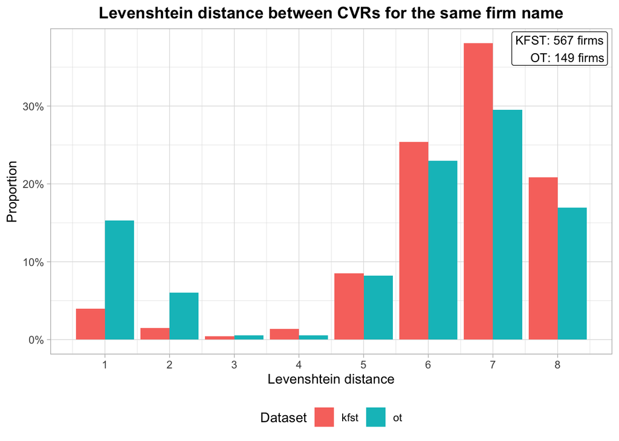

## 7.2 Improved fuzzy matching

We could improve the fuzzy matching by requiring that the second best candidate name is much worse than the first best candidate. This prevents fragile differences from being detected as highly likely matches.

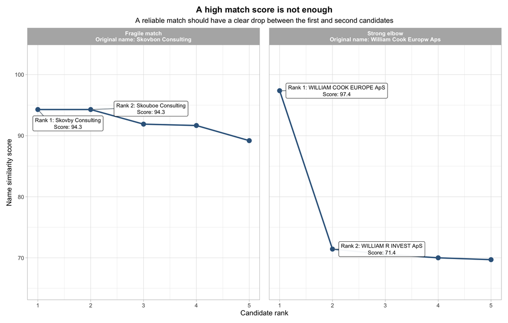

## 7.3 Updating firm-cvr number key

The matching process relies on a key of firm names and CVR numbers that ends in 2020. I test whether this limits matching by comparing the unmatched rate across tender years. The unmatched rate is the number of candidates without an automatic match divided by all matching candidates in that year. This is more useful than the unmatched count because the number of tenders changes over time.

For KFST, I use the tender publication year. For OpenTender, I use the year of the first contract award publication. This is also the date used in the matching process. OpenTender source rows are counted once, including rows that were later split into several firms. Each panel shows its observed year range. The KFST series begins in 2017 because there are no KFST matching candidates with an earlier publication year.

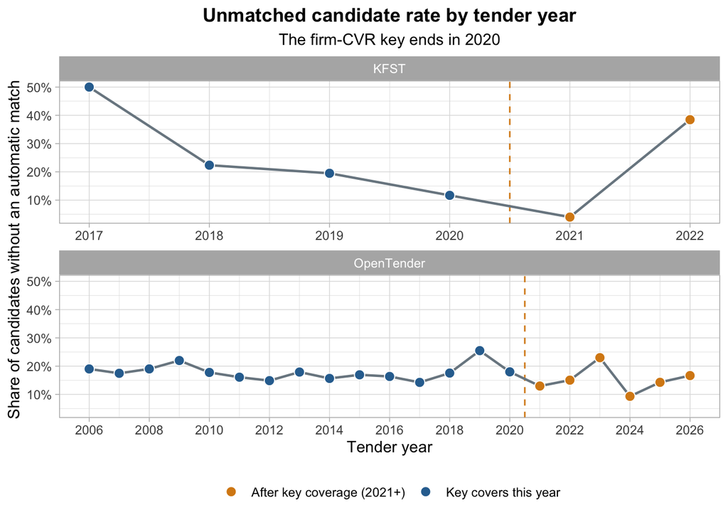

Unmatched candidates before and after the end of the key

| Dataset | Period | Candidates | Unmatched | Unmatched rate |
| --- | --- | --- | --- | --- |
| KFST | Up to 2020 | 638 | 104 | 16.3% |
| KFST | 2021 onwards | 163 | 11 | 6.7% |
| OpenTender | Up to 2020 | 20,747 | 3,655 | 17.6% |
| OpenTender | 2021 onwards | 4,568 | 791 | 17.3% |

## 7.4 Verifying data

We could also use the CVR number to name key to verify that the name in the source data is correct. This would help validate the data splitting process I’ve undertaken, for example.